# 9. Solving Linear Equations

Michael Friendly and John Fox

2025-10-05

This vignette illustrates the ideas behind solving systems of linear equations of the form $\mathbf{A x = b}$ where

- $\mathbf{A}$ is an $m \times n$ matrix of coefficients for $m$ equations in $n$ unknowns
- $\mathbf{x}$ is an $n \times 1$ vector unknowns, $x_1, x_2, \dots x_n$
- $\mathbf{b}$ is an $m \times 1$ vector of constants, the “right-hand sides” of the equations

or, spelled out,

$$\begin{bmatrix}
a_{11} & a_{12} & \cdots & a_{1n} \\
a_{21} & a_{22} & \cdots & a_{2n} \\
\vdots & \vdots & & \vdots \\
a_{m1} & a_{m2} & \cdots & a_{mn} \\
\end{bmatrix}
\begin{pmatrix}
x_{1} \\
x_{2} \\
\vdots \\
x_{n} \\
\end{pmatrix}
\quad=\quad
\begin{pmatrix}
b_{1} \\
b_{2} \\
\vdots \\
b_{m} \\
\end{pmatrix}$$
For three equations in three unknowns, the equations look like this:

```r
A <- matrix(paste0("a_{", outer(1:3, 1:3, FUN  = paste0), "}"),
            nrow=3)
b <- paste0("b_", 1:3)
x <- paste0("x", 1:3)
showEqn(A, b, vars = x, latex=TRUE)
```

$$\begin{array}{lllllll}
a_{11} \cdot x_1 &+& a_{12} \cdot x_2 &+& a_{13} \cdot
x_3 &=& b_1 \\
a_{21} \cdot x_1 &+& a_{22} \cdot x_2 &+& a_{23} \cdot
x_3 &=& b_2 \\
a_{31} \cdot x_1 &+& a_{32} \cdot x_2 &+& a_{33} \cdot
x_3 &=& b_3 \\
\end{array}$$

## Conditions for a solution

The general conditions for solutions are:

- the equations are *consistent* (solutions exist) if $r( \mathbf{A} | \mathbf{b}) = r( \mathbf{A})$
  - the solution is *unique* if $r( \mathbf{A} | \mathbf{b}) = r( \mathbf{A}) = n$
  - the solution is *underdetermined* if $r( \mathbf{A} | \mathbf{b}) = r( \mathbf{A}) < n$
- the equations are *inconsistent* (no solutions) if $r( \mathbf{A} | \mathbf{b}) > r( \mathbf{A})$

We use `c( R(A), R(cbind(A,b)) )` to show the ranks, and `all.equal( R(A), R(cbind(A,b)) )` to test for consistency.

```r
library(matlib)   # use the package
```

## Equations in two unknowns

Each equation in two unknowns corresponds to a line in 2D space. The equations have a unique solution if all lines intersect in a point.

### Two consistent equations

```r
A <- matrix(c(1, 2, -1, 2), 2, 2)
b <- c(2,1)
showEqn(A, b)
```

```
## 1*x1 - 1*x2  =  2
## 2*x1 + 2*x2  =  1
```

Check whether they are consistent:

```r
c( R(A), R(cbind(A,b)) )          # show ranks
```

```
## [1] 2 2
```

```r
all.equal( R(A), R(cbind(A,b)) )  # consistent?
```

```
## [1] TRUE
```

Plot the equations:

```
##   x[1] - 1*x[2]  =  2
## 2*x[1] + 2*x[2]  =  1
```

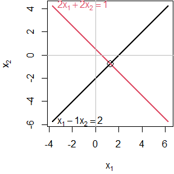

```r
plotEqn(A,b)
```

`Solve()` is a convenience function that shows the solution in a more comprehensible form:

```r
Solve(A, b, fractions = TRUE)
```

```
## x1    =   5/4
##   x2  =  -3/4
```

### Three consistent equations

For three (or more) equations in two unknowns, $r(\mathbf{A}) \le 2$, because $r(\mathbf{A}) \le \min(m,n)$. The equations will be consistent *if* $r(\mathbf{A}) = r(\mathbf{A | b})$. This means that whatever linear relations exist among the rows of $\mathbf{A}$ are the *same* as those among the elements of $\mathbf{b}$.

Geometrically, this means that all three lines intersect in a point.

```r
A <- matrix(c(1,2,3, -1, 2, 1), 3, 2)
b <- c(2,1,3)
showEqn(A, b)
```

```
## 1*x1 - 1*x2  =  2
## 2*x1 + 2*x2  =  1
## 3*x1 + 1*x2  =  3
```

```r
c( R(A), R(cbind(A,b)) )          # show ranks
```

```
## [1] 2 2
```

```r
all.equal( R(A), R(cbind(A,b)) )  # consistent?
```

```
## [1] TRUE
```

```r
Solve(A, b, fractions=TRUE)       # show solution
```

```
## x1    =   5/4
##   x2  =  -3/4
##    0  =     0
```

Plot the equations:

```
##   x[1] - 1*x[2]  =  2
## 2*x[1] + 2*x[2]  =  1
## 3*x[1]   + x[2]  =  3
```

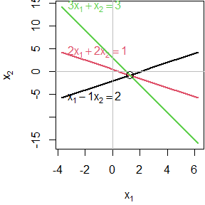

```r
plotEqn(A,b)
```

### Three inconsistent equations

Three equations in two unknowns are *inconsistent* when $r(\mathbf{A}) < r(\mathbf{A | b})$.

```r
A <- matrix(c(1,2,3, -1, 2, 1), 3, 2)
b <- c(2,1,6)
showEqn(A, b)
```

```
## 1*x1 - 1*x2  =  2
## 2*x1 + 2*x2  =  1
## 3*x1 + 1*x2  =  6
```

```r
c( R(A), R(cbind(A,b)) )          # show ranks
```

```
## [1] 2 3
```

```r
all.equal( R(A), R(cbind(A,b)) )  # consistent?
```

```
## [1] "Mean relative difference: 0.5"
```

You can see this in the result of reducing $\mathbf{A} | \mathbf{b}$ to echelon form, where the last row indicates the inconsistency because it represents the equation $0 x_1 + 0 x_2 = -3$.

```r
echelon(A, b)
```

```
##      [,1] [,2]  [,3]
## [1,]    1    0  2.75
## [2,]    0    1 -2.25
## [3,]    0    0 -3.00
```

`Solve()` shows this more explicitly, using fractions where possible:

```r
Solve(A, b, fractions=TRUE)
```

```
## x1    =  11/4
##   x2  =  -9/4
##    0  =    -3
```

An approximate solution is sometimes available using a generalized inverse. This gives $\mathbf{x} = (2, -1)$ as a best close solution.

```r
x <- MASS::ginv(A) %*% b
x
```

```
##      [,1]
## [1,]    2
## [2,]   -1
```

Plot the equations. You can see that each pair of equations has a solution, but all three do not have a common, consistent solution.

```r
par(mar=c(4,4,0,0)+.1)
plotEqn(A,b, xlim=c(-2, 4))
```

```
##   x[1] - 1*x[2]  =  2
## 2*x[1] + 2*x[2]  =  1
## 3*x[1]   + x[2]  =  6
```

```r
# add the ginv() solution
points(x[1], x[2], pch=15)
```

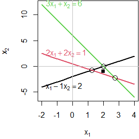

## Equations in three unknowns

Each equation in three unknowns corresponds to a plane in 3D space. The equations have a unique solution if all planes intersect in a point.

### Three consistent equations

An example:

```r
A <- matrix(c(2, 1, -1,
             -3, -1, 2,
             -2,  1, 2), 3, 3, byrow=TRUE)
colnames(A) <- paste0('x', 1:3)
b <- c(8, -11, -3)
showEqn(A, b)
```

```
##  2*x1 + 1*x2 - 1*x3  =    8
## -3*x1 - 1*x2 + 2*x3  =  -11
## -2*x1 + 1*x2 + 2*x3  =   -3
```

Are the equations consistent?

```r
c( R(A), R(cbind(A,b)) )          # show ranks
```

```
## [1] 3 3
```

```r
all.equal( R(A), R(cbind(A,b)) )  # consistent?
```

```
## [1] TRUE
```

Solve for $\mathbf{x}$.

```r
solve(A, b)
```

```
## x1 x2 x3
##  2  3 -1
```

Other ways of solving:

```r
solve(A) %*% b
```

```
##    [,1]
## x1    2
## x2    3
## x3   -1
```

```r
inv(A) %*% b
```

```
##      [,1]
## [1,]    2
## [2,]    3
## [3,]   -1
```

Yet another way to see the solution is to reduce $\mathbf{A | b}$ to echelon form. The result of this is the matrix $[\mathbf{I \quad | \quad A^{-1}b}]$, with the solution in the last column.

```r
echelon(A, b)
```

```
##      x1 x2 x3
## [1,]  1  0  0  2
## [2,]  0  1  0  3
## [3,]  0  0  1 -1
```

`echelon() can be asked to show the steps, as the row operations necessary to reduce $\mathbf{X}$ to the identity matrix $\mathbf{I}$.

```r
echelon(A, b, verbose=TRUE, fractions=TRUE)
```

```
##
## Initial matrix:
```

```
##      x1  x2  x3
## [1,]   2   1  -1   8
## [2,]  -3  -1   2 -11
## [3,]  -2   1   2  -3
##
## row: 1
##
##  exchange rows 1 and 2
```

```
##      x1  x2  x3
## [1,]  -3  -1   2 -11
## [2,]   2   1  -1   8
## [3,]  -2   1   2  -3
##
##  multiply row 1 by -1/3
```

```
##      x1   x2   x3
## [1,]    1  1/3 -2/3 11/3
## [2,]    2    1   -1    8
## [3,]   -2    1    2   -3
##
##  multiply row 1 by 2 and subtract from row 2
```

```
##      x1   x2   x3
## [1,]    1  1/3 -2/3 11/3
## [2,]    0  1/3  1/3  2/3
## [3,]   -2    1    2   -3
##
##  multiply row 1 by 2 and add to row 3
```

```
##      x1   x2   x3
## [1,]    1  1/3 -2/3 11/3
## [2,]    0  1/3  1/3  2/3
## [3,]    0  5/3  2/3 13/3
##
## row: 2
##
##  exchange rows 2 and 3
```

```
##      x1   x2   x3
## [1,]    1  1/3 -2/3 11/3
## [2,]    0  5/3  2/3 13/3
## [3,]    0  1/3  1/3  2/3
##
##  multiply row 2 by 3/5
```

```
##      x1   x2   x3
## [1,]    1  1/3 -2/3 11/3
## [2,]    0    1  2/5 13/5
## [3,]    0  1/3  1/3  2/3
##
##  multiply row 2 by 1/3 and subtract from row 1
```

```
##      x1   x2   x3
## [1,]    1    0 -4/5 14/5
## [2,]    0    1  2/5 13/5
## [3,]    0  1/3  1/3  2/3
##
##  multiply row 2 by 1/3 and subtract from row 3
```

```
##      x1   x2   x3
## [1,]    1    0 -4/5 14/5
## [2,]    0    1  2/5 13/5
## [3,]    0    0  1/5 -1/5
##
## row: 3
##
##  multiply row 3 by 5
```

```
##      x1   x2   x3
## [1,]    1    0 -4/5 14/5
## [2,]    0    1  2/5 13/5
## [3,]    0    0    1   -1
##
##  multiply row 3 by 4/5 and add to row 1
```

```
##      x1   x2   x3
## [1,]    1    0    0    2
## [2,]    0    1  2/5 13/5
## [3,]    0    0    1   -1
##
##  multiply row 3 by 2/5 and subtract from row 2
```

```
##      x1 x2 x3
## [1,]  1  0  0  2
## [2,]  0  1  0  3
## [3,]  0  0  1 -1
```

Now, let’s plot them.

`plotEqn3d()` uses `rgl` for 3D graphics. If you rotate the figure, you’ll see an orientation where all three planes intersect at the solution point, $\mathbf{x} = (2, 3, -1)$

```r
plotEqn3d(A,b, xlim=c(0,4), ylim=c(0,4))
```

[interactive chart not shown]

### Three inconsistent equations

```r
A <- matrix(c(1,  3, 1,
              1, -2, -2,
              2,  1, -1), 3, 3, byrow=TRUE)
colnames(A) <- paste0('x', 1:3)
b <- c(2, 3, 6)
showEqn(A, b)
```

```
## 1*x1 + 3*x2 + 1*x3  =  2
## 1*x1 - 2*x2 - 2*x3  =  3
## 2*x1 + 1*x2 - 1*x3  =  6
```

Are the equations consistent? No.

```r
c( R(A), R(cbind(A,b)) )          # show ranks
```

```
## [1] 2 3
```

```r
all.equal( R(A), R(cbind(A,b)) )  # consistent?
```

```
## [1] "Mean relative difference: 0.5"
```